# Business-Case-Apollo-Hospitals-Hypothesis-Testing

`Problem statment`

Apollo Hospitals was established in 1983, renowned as the architect of modern healthcare in India. As the nation's first corporate hospital, Apollo Hospitals is acclaimed for pioneering the private healthcare revolution in the country.

As a data scientist working at Apollo 24/7, the ultimate goal is to tease out meaningful and actionable insights from Patient-level collected data.

You can help Apollo hospitals to be more efficient, to influence diagnostic and treatment processes, to map the spread of a pandemic.

One of the best examples of data scientists making a meaningful difference at a global level is in the response to the COVID-19 pandemic, where they have improved information collection, provided ongoing and accurate estimates of infection spread and health system demand, and assessed the effectiveness of government policies.

`Company want to know`

• Which variables are significant in predicting the reason for hospitalization for different regions

• How well some variables like viral load, smoking, Severity Level describe the hospitalization charges

`Column Profiling`

`Age`: This is an integer indicating the age of the primary beneficiary (excluding those above 64 years, since they are generally covered by the government).

`Sex`: This is the policy holder's gender, either male or female

`Viral Load`: Viral load refers to the amount of virus in an infected person's blood

`Severity Level`: This is an integer indicating how severe the patient is

`Smoker`: This is yes or no depending on whether the insured regularly smokes tobacco.

`Region`: This is the beneficiary's place of residence in Delhi, divided into four geographic regions - northeast, southeast, southwest, or northwest

`Hospitalization charges`: Individual medical costs billed to health insurance

```python
import pandas as pd
import numpy as np
from scipy.stats import *
import seaborn as sns
import matplotlib.pyplot as plt
```

```python
data = pd.read_csv('scaler_apollo_hospitals.csv',index_col='Unnamed: 0')
```

```python
data.head()
```

|  | age | sex | smoker | region | viral load | severity level | hospitalization charges |
| --- | --- | --- | --- | --- | --- | --- | --- |
| 0 | 19 | female | yes | southwest | 9.30 | 0 | 42212 |
| 1 | 18 | male | no | southeast | 11.26 | 1 | 4314 |
| 2 | 28 | male | no | southeast | 11.00 | 3 | 11124 |
| 3 | 33 | male | no | northwest | 7.57 | 0 | 54961 |
| 4 | 32 | male | no | northwest | 9.63 | 0 | 9667 |

# Shape of data

```python
data.shape
```

```
(1338, 7)
```

# Null Column check

```python
data.isna().sum()
```

```
age                        0
sex                        0
smoker                     0
region                     0
viral load                 0
severity level             0
hospitalization charges    0
dtype: int64
```

```python
data.info()
```

```
<class 'pandas.core.frame.DataFrame'>
Int64Index: 1338 entries, 0 to 1337
Data columns (total 7 columns):
 #   Column                   Non-Null Count  Dtype
---  ------                   --------------  -----
 0   age                      1338 non-null   int64
 1   sex                      1338 non-null   object
 2   smoker                   1338 non-null   object
 3   region                   1338 non-null   object
 4   viral load               1338 non-null   float64
 5   severity level           1338 non-null   int64
 6   hospitalization charges  1338 non-null   int64
dtypes: float64(1), int64(3), object(3)
memory usage: 83.6+ KB
```

```python
data.describe()
```

|  | age | viral load | severity level | hospitalization charges |
| --- | --- | --- | --- | --- |
| count | 1338.000000 | 1338.000000 | 1338.000000 | 1338.000000 |
| mean | 39.207025 | 10.221233 | 1.094918 | 33176.058296 |
| std | 14.049960 | 2.032796 | 1.205493 | 30275.029296 |
| min | 18.000000 | 5.320000 | 0.000000 | 2805.000000 |
| 25% | 27.000000 | 8.762500 | 0.000000 | 11851.000000 |
| 50% | 39.000000 | 10.130000 | 1.000000 | 23455.000000 |
| 75% | 51.000000 | 11.567500 | 2.000000 | 41599.500000 |
| max | 64.000000 | 17.710000 | 5.000000 | 159426.000000 |

# Univariate analysis of given data

```python
def plot_countplot(main_data,data,title):
    plt.title(title)
    sns.countplot(data = main_data,x=data)
    plt.show()

def plot_histogram(data,title,bins=20,kde=False):
    plt.title(title)
    sns.histplot(data=data,kde=kde,bins=bins)
    plt.show()
```

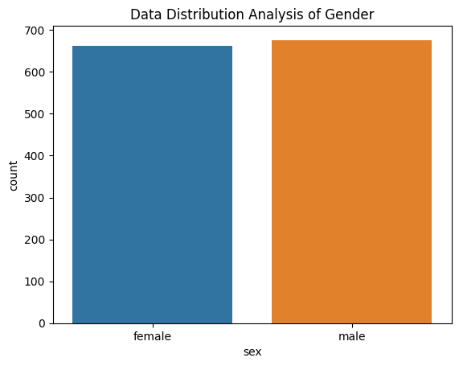

```
Analysis

It is observed that male policy holders are more than female policy holders
```

```python
Gender = data['sex']
title='Data Distribution Analysis of Gender'
plot_countplot(data,Gender,title)
analysis = "It is observed that male policy holders are more than female policy holders"
print(f'Analysis\n \n{analysis}')
```

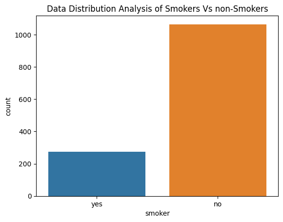

```
Analysis

It is observed that non-smokers insured person are more than insured person who smokes
```

```python
Smokers = data['smoker']
title='Data Distribution Analysis of Smokers Vs non-Smokers'
plot_countplot(data,Smokers,title)
analysis = "It is observed that non-smokers insured person are more than insured person who smokes"
print(f'Analysis\n \n{analysis}')
```

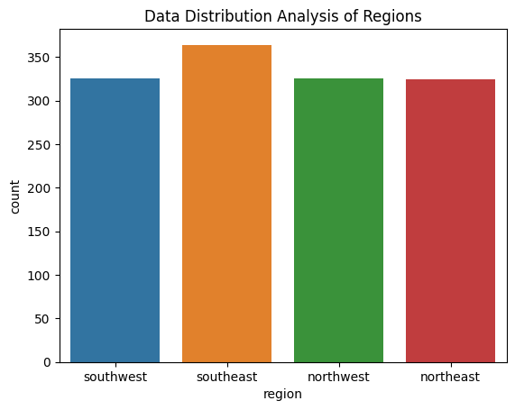

```
Analysis

It is observed that beneficiary's from southeast region is higher than other region beneficiary.
```

```python
Regions = data['region']
title='Data Distribution Analysis of Regions'
plot_countplot(data,Regions,title)
analysis = "It is observed that beneficiary's from southeast region is higher than other region beneficiary."
print(f'Analysis\n\n{analysis}')
```

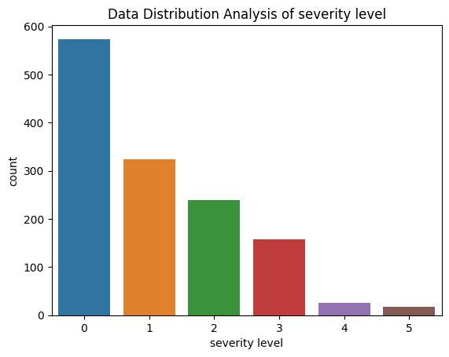

```
Analysis

It is observed that patients with zero severity level are higher than patients with severity level five
```

```python
Regions = data['severity level']
title='Data Distribution Analysis of severity level'
plot_countplot(data,Regions,title)
analysis = "It is observed that patients with zero severity level are higher than patients with severity level five"
print(f'Analysis\n\n{analysis}')
```

# Data Distribution Analysis Numerical Data

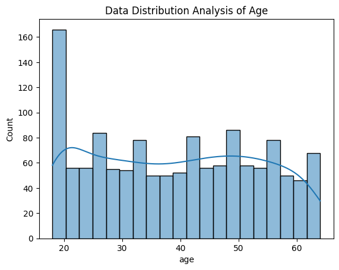

```python
Age = data['age']
title='Data Distribution Analysis of Age'
bins=20
plot_histogram(Age,title,bins,kde=True)
```

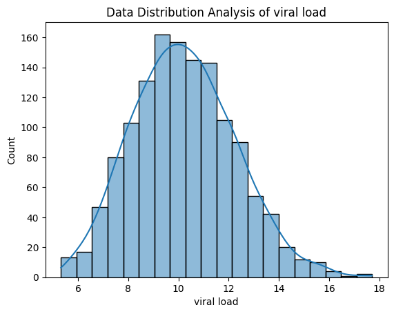

```python
viral_load = data['viral load']
title='Data Distribution Analysis of viral load'
bins=20
plot_histogram(viral_load,title,bins,kde=True)
```

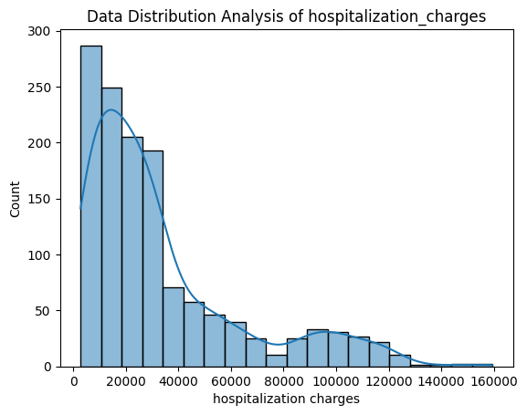

```python
hospitalization_charges = data['hospitalization charges']
title='Data Distribution Analysis of hospitalization_charges'
bins=20
plot_histogram(hospitalization_charges,title,bins,kde=True)
```

# Bivariate Data Distribution Analysis

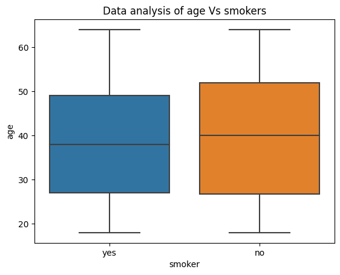

```python
Age = data['age']
smokers = data['smoker']
plt.title('Data analysis of age Vs smokers')
sns.boxplot(data=data,x=smokers,y=Age,orient='v')
plt.show()
```

```python
def get_IQR_calculation(data):
    data = sorted(data)
    Q1,Q2,Q3 = np.percentile(data,[25,50,75])
    IQR = Q3-Q1
    left_wisker = Q1-(1.5*IQR)
    right_wisker = Q3+(1.5*IQR)

    print(f'Q1: {Q1} ,Q2 : {Q2} , Q3: {Q3} , left_wisker:{left_wisker} , right_wisker:{right_wisker}')
```

```python
smoker_age = data.loc[data['smoker']=='yes']['age']
get_IQR_calculation(smoker_age)
```

```
Q1: 27.0 ,Q2 : 38.0 , Q3: 49.0 , left_wisker:-6.0 , right_wisker:82.0
```

```python
non_smoker_age = data.loc[data['smoker']=='no']['age']
get_IQR_calculation(non_smoker_age)

Observation = "It is observed that Average age of patients who smokes are of age 38 and Average age of patients who don't smoke are of age 40"
print(f'\n\nObservation\n\n{Observation}')
```

```
Q1: 26.75 ,Q2 : 40.0 , Q3: 52.0 , left_wisker:-11.125 , right_wisker:89.875


Observation

It is observed that Average age of patients who smokes are of age 38 and Average age of patients who don't smoke are of age 40
```

```python
data.head()
```

|  | age | sex | smoker | region | viral load | severity level | hospitalization charges |
| --- | --- | --- | --- | --- | --- | --- | --- |
| 0 | 19 | female | yes | southwest | 9.30 | 0 | 42212 |
| 1 | 18 | male | no | southeast | 11.26 | 1 | 4314 |
| 2 | 28 | male | no | southeast | 11.00 | 3 | 11124 |
| 3 | 33 | male | no | northwest | 7.57 | 0 | 54961 |
| 4 | 32 | male | no | northwest | 9.63 | 0 | 9667 |

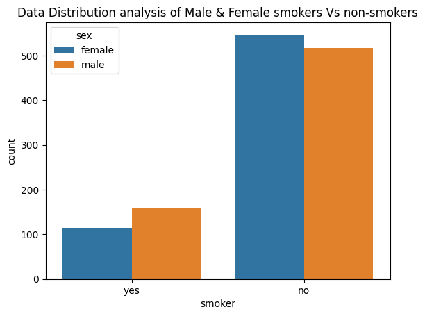

```
Analysis

It can be observed that male as well as female non-smokers population are more than male & female smoker population.
```

```python
plt.title('Data Distribution analysis of Male & Female smokers Vs non-smokers')
sns.countplot(data=data,x='smoker',hue='sex')
plt.show()
analysis = 'It can be observed that male as well as female non-smokers population are more than male & female smoker population.'
print(f'Analysis\n\n{analysis}')
```

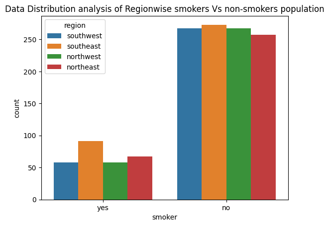

```python
plt.title('Data Distribution analysis of Regionwise smokers Vs non-smokers population')
sns.countplot(data=data,x='smoker',hue='region')
plt.show()
```

# Outlier treatment of hospitalization charges feature.

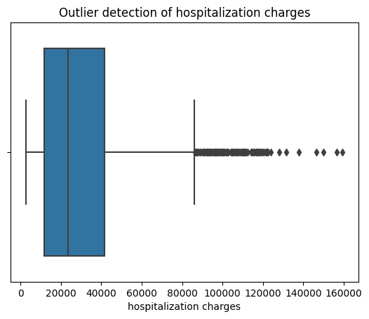

```python
plt.title('Outlier detection of hospitalization charges')
sns.boxplot(data=data,x='hospitalization charges',orient='h')
plt.show()
```

```python
sample = data['hospitalization charges']
outliers = []
def detect_outliers_iqr(data):
    data = sorted(data)
    q1 = np.percentile(data, 25)
    q3 = np.percentile(data, 75)
    # print(q1, q3)
    IQR = q3-q1
    lwr_bound = q1-(1.5*IQR)
    upr_bound = q3+(1.5*IQR)
    # print(lwr_bound, upr_bound)
    for i in data:
        if (i<lwr_bound or i>upr_bound):
            outliers.append(i)
    return outliers# Driver code
sample_outliers = detect_outliers_iqr(sample)
print("Outliers from IQR method: ", sample_outliers)
```

```
Outliers from IQR method:  [86545, 86680, 86949, 87016, 87072, 87097, 87673, 87869, 87900, 88729, 88964, 88989, 90053, 90213, 90311, 90374, 90473, 90494, 90549, 90769, 90994, 91451, 92094, 92247, 92277, 92376, 92698, 92835, 92913, 93175, 93663, 93711, 94019, 94255, 94356, 94574, 95316, 95614, 95707,…
```

```python
tenth_percentile = np.percentile(sample, 10)
ninetieth_percentile = np.percentile(sample, 90)
# print(tenth_percentile, ninetieth_percentile)
b = np.where(sample<tenth_percentile, tenth_percentile, sample)
b = np.where(b>ninetieth_percentile, ninetieth_percentile, b)
# print("Sample:", sample)
print("New array:",b)
```

```
New array: [42212.   5866.1 11124.  ...  5866.1  5866.1 72853. ]
```

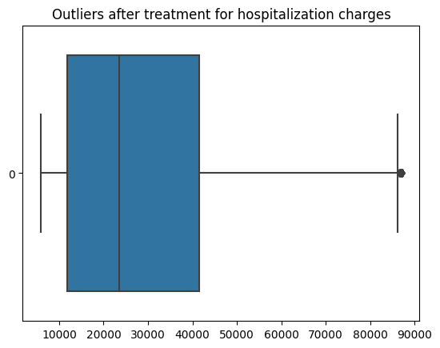

```python
plt.title('Outliers after treatment for hospitalization charges')
sns.boxplot(b,orient='h')
plt.show()
```

```python
charges = b
```

```python
data['hospitalization charges'] = charges
```

# Hypothesis testing to check how well severity_level defines hospitalization_charges

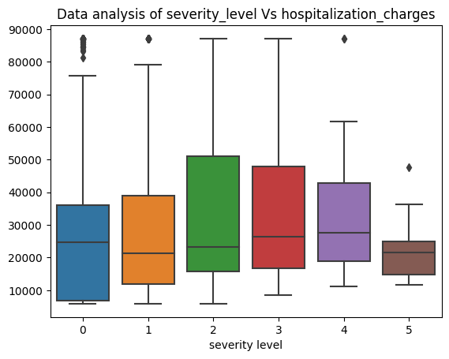

```python
severity_level = data['severity level']
hospitalization_charges = charges
plt.title('Data analysis of severity_level Vs hospitalization_charges')
sns.boxplot(data=data,x=severity_level,y=hospitalization_charges,orient='v')
plt.show()
```

```python
severity_zero = data.loc[severity_level==0]['hospitalization charges']
severity_one = data.loc[severity_level==1]['hospitalization charges']
severity_two = data.loc[severity_level==2]['hospitalization charges']
severity_three = data.loc[severity_level==3]['hospitalization charges']
severity_four = data.loc[severity_level==4]['hospitalization charges']
severity_five = data.loc[severity_level==5]['hospitalization charges']
```

We will use ANOVA test to check this hypothesis below are the condition for ANOVA test

1. Normality - > must follow normal distribution
2. Independent
3. Equal Sample varience.

# Since we can see data is not following normal distribution so we cannot proceed with ANOVA. So instead of `ANOVA` we will use `Levene Test`.

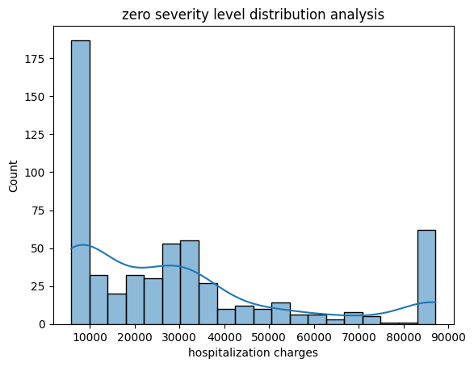

```python
bins=20
plot_histogram(severity_zero,'zero severity level distribution analysis',bins,kde=True)
```

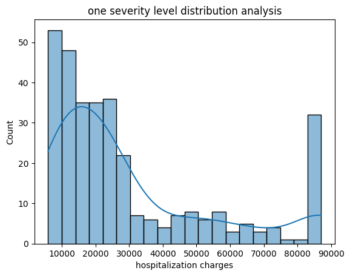

```python
plot_histogram(severity_one,'one severity level distribution analysis',bins,kde=True)
```

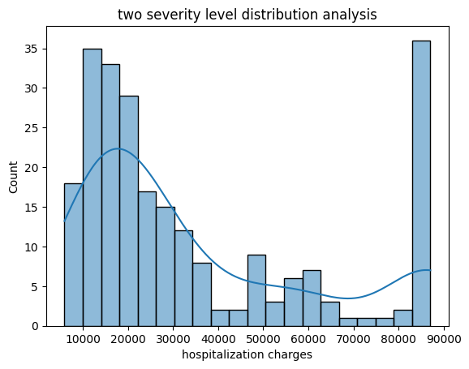

```python
plot_histogram(severity_two,'two severity level distribution analysis',bins,kde=True)
```

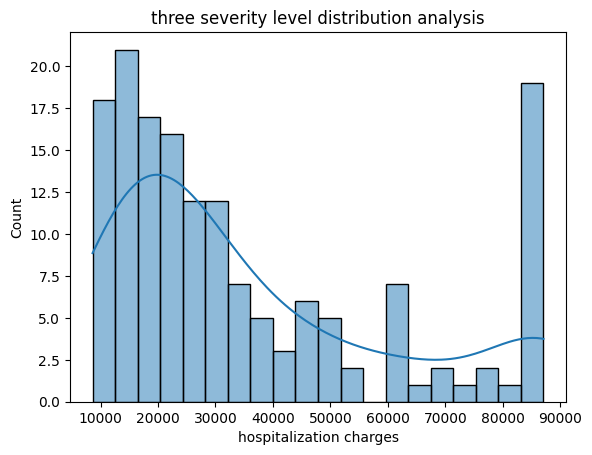

```python
plot_histogram(severity_three,'three severity level distribution analysis',bins,kde=True)
```

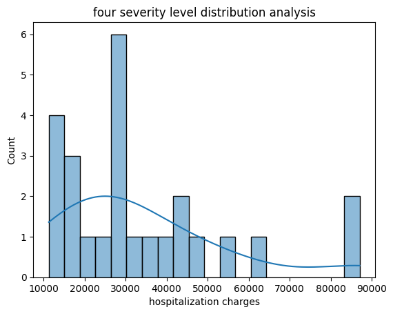

```python
plot_histogram(severity_four,'four severity level distribution analysis',bins,kde=True)
```

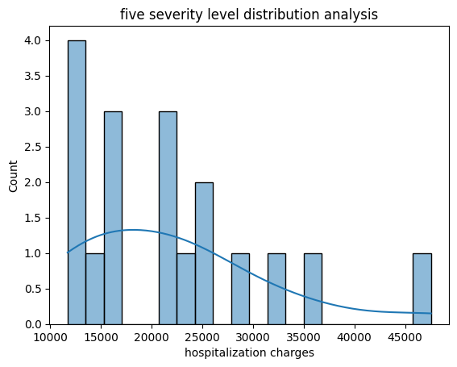

```python
plot_histogram(severity_five,'five severity level distribution analysis',bins,kde=True)
```

# Check for type of skewness for hospitalization charges

Skewness is a measure of the asymmetry of a distribution. This value can be positive or negative.

A negative skew indicates that the tail is on the left side of the distribution, which extends towards more negative values.

A positive skew indicates that the tail is on the right side of the distribution, which extends towards more positive values.

A value of zero indicates that there is no skewness in the distribution at all, meaning the distribution is perfectly symmetrical.